# OLS: Diagnostics

## Step 8: Model Selection

We now have several candidate models: the misspecified baseline (`ols.base`), the polynomial-corrected model (`ols.clean`), the WLS version (`wls.clean`), and the log-transformed version (`ols.log`). How do we choose?

The right comparison depends on what you’re trying to accomplish. Here are the tools we’ll use:

- **ANOVA F-test** (`anova()`) — valid for nested models (one model is a special case of the other); tests whether the additional parameters significantly improve fit.
- **AIC and BIC** — information criteria that penalize model complexity; lower is better. BIC penalizes extra parameters more heavily than AIC, reflecting a stronger preference for parsimony. For *inference* (as opposed to prediction), lean on BIC.
- **`performance::compare_performance()`** — gives you AIC, BIC, $R^2$, RMSE, and a ranking in one table.

First, let’s compare the misspecified baseline to the polynomial-corrected model. These are nested (the baseline is a special case of the polynomial model where the $x_2^2$ coefficient is zero):

```r
ols.base2 <- lm(y ~ x_1 + x_2 + x_3,     # drop obs not in ols.clean
               data = sim.df,
               subset = names(residuals(ols.clean)))

anova(ols.base2, ols.clean, test = "F")
```

```
## Analysis of Variance Table
##
## Model 1: y ~ x_1 + x_2 + x_3
## Model 2: y ~ x_1 + poly(x_2, 2, raw = TRUE) + x_3
##   Res.Df   RSS Df Sum of Sq    F  Pr(>F)
## 1    296 47335
## 2    295 45125  1      2210 14.4 0.00018 ***
## ---
## Signif. codes:  0 '***' 0.001 '**' 0.01 '*' 0.05 '.' 0.1 ' ' 1
```

The F-test strongly prefers the polynomial model. Now let’s do a broader comparison across all specifications:

```r
comp <- compare_performance(
  ols.base, ols.clean, wls.clean, ols.log,
  rank = TRUE
)

comp$Name <- c("Baseline (misspecified)", "Polynomial OLS",
               "WLS", "Log-Lin")

kable(comp,
      caption = "Model Comparison",
      digits  = 3) %>%
  kable_styling(full_width = TRUE)
```

Table 5: Table 6: Model Comparison

[output not shown]

The metrics are pointing in different directions. Which model do I pick?

This is where the art comes in. A few principles to guide the decision: (1) **A model that fixes a real problem is better than one that doesn’t**, even if the fit statistics are similar. If WLS or HC-robust SEs actually resolve the heteroscedasticity, that matters for your inference even if $R^2$ looks similar. (2) **Prioritize BIC over AIC for inference** — it penalizes complexity more and discourages overfitting when your goal is to understand coefficients, not to make predictions. (3) **The log-transformed model changes the estimand** — if your research question is about absolute changes in $y$, a log-lin model gives you a different answer. Make sure the model you choose is answering the question you’re asking. (4) **Look at the substantive differences in effects**, not just the fit statistics. If your key coefficient barely changes across specifications, you have good evidence of robustness.

For this example, we’ll go with the polynomial OLS model with HC-robust standard errors (`ols.clean` + `vcovHC`). The RESET test clears, the functional form is correct, and HC standard errors give us honest inference without changing the coefficient estimates.

## Step 9: Presenting the Final Results

Once you’ve settled on a model, you need to present it clearly. This means three things: a clean regression table, an honest comparison to the baseline, and effects plots that communicate the substantive story.

### Regression Table

```r
# define coefficient labels
labz <- list(
  "(Intercept)"              = "Intercept",
  "x_1"                      = "$x_1$",
  "poly(x_2, 2, raw = TRUE)1" = "$x_2$",
  "poly(x_2, 2, raw = TRUE)2" = "$x_2^2$",
  "x_3"                      = "$x_3$"
)

htmlreg(list("Baseline OLS" = ols.base,
             "Final Model (HC SE)" = hc1.clean),
        format        = "apsr",
        custom.coef.map = labz,
        caption         = "Baseline vs. Final Model",
        caption.above   = TRUE,
        single.row      = FALSE,
        stars           = c(0.001, 0.01, 0.05))
```

Baseline vs. Final Model

|  | Baseline OLS | Final Model (HC SE) |
| --- | --- | --- |
| Intercept | -1.33 | 0.38 |
|  | (1.99) | (1.13) |
| $x_1$ | 2.43** | 2.65*** |
|  | (0.79) | (0.74) |
| $x_2$ |  | 3.84*** |
|  |  | (0.58) |
| $x_2^2$ |  | -1.66*** |
|  |  | (0.32) |
| $x_3$ | 0.21 | -0.23 |
|  | (0.98) | (0.80) |
| R<sup>2</sup> | 0.20 |  |
| Adj. R<sup>2</sup> | 0.19 |  |
| Num. obs. | 303 |  |

***p < 0.001; **p < 0.01; *p < 0.05

### Effects Plots

For main effects and any polynomial or interaction terms, `ggpredict()` from `ggeffects` is your friend. It plots the predicted values of $y$ across the range of a predictor, holding all other predictors at their means (or at values you specify). This is the right way to communicate the substantive size of an effect.

Figure 11: Marginal predicted values of y across the range of each predictor. The HC-robust confidence intervals are passed via the vcov argument.

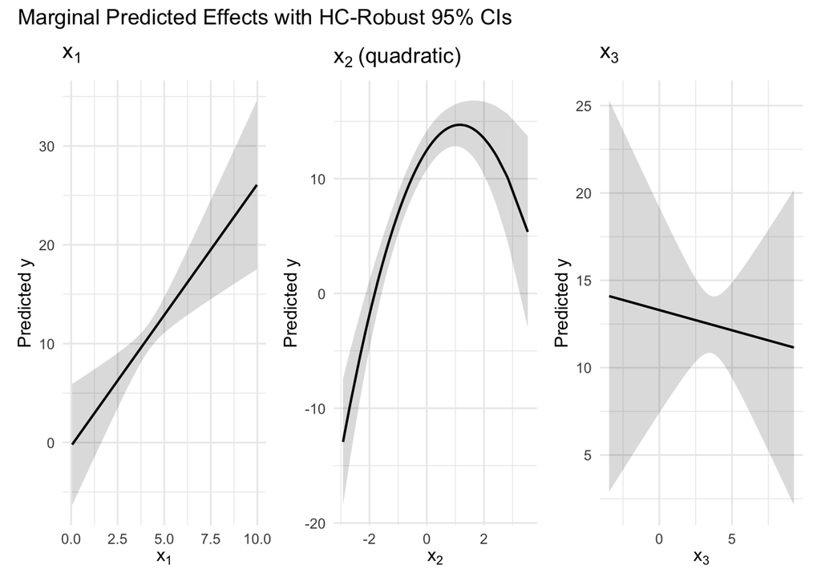

```r
# generate predictions with HC-robust standard errors
pred.x1 <- ggpredict(ols.clean, terms = "x_1",
                     vcov = vcovHC(ols.clean, type = "HC1"))
pred.x2 <- ggpredict(ols.clean, terms = "x_2 [all]",
                     vcov = vcovHC(ols.clean, type = "HC1"))
pred.x3 <- ggpredict(ols.clean, terms = "x_3",
                     vcov = vcovHC(ols.clean, type = "HC1"))

p1 <- plot(pred.x1) +
  labs(title = expression(x[1]),
       x = expression(x[1]), y = "Predicted y") +
  theme_minimal()

p2 <- plot(pred.x2) +
  labs(title = expression(x[2] ~ "(quadratic)"),
       x = expression(x[2]), y = "Predicted y") +
  theme_minimal()

p3 <- plot(pred.x3) +
  labs(title = expression(x[3]),
       x = expression(x[3]), y = "Predicted y") +
  theme_minimal()

p1 + p2 + p3 +
  plot_annotation(title = "Marginal Predicted Effects with HC-Robust 95% CIs")
```

## A Final Word on the Workflow

The nine steps above aren’t a rigid checklist — they’re a logical sequence built around two ideas: (1) fix problems before you diagnose the things that those problems contaminate, and (2) make modeling decisions for substantive reasons, not just because a test came back significant.

In practice, the workflow is iterative. You might fix nonlinearity in Step 4 and then discover in Step 5 that two of your apparent outliers have vanished. You might find in Step 7 that a log transformation of $y$ resolves both the heteroscedasticity *and* the non-normality from Step 6, meaning you can go back and simplify. That’s not a sign you did something wrong — it’s the diagnostic process working as intended.

The goal isn’t a model that passes every test. The goal is a model whose assumptions you’ve genuinely interrogated, whose problems you’ve honestly addressed, and whose results you can defend.

## References

[^1]: For a thorough treatment of multicollinearity — including perfect, essential, and structural types — see my standalone document on the topic at `studycourts.github.io/gradData/multicollinearity.html`.
[^2]: See Homework 8 for a detailed worked example of this comparison, including the logic of choosing between polynomial and spline specifications for inferential vs. predictive goals.
[^3]: For a full treatment of outlier types, simulation-based visualizations, and treatment strategies, see my standalone outliers document at `studycourts.github.io/gradData/outliers.html`.
[^4]: If your DV has zero or negative values, you’ll need to add a constant before logging. A common choice is the absolute value of the most negative observation plus a small buffer. For example, if the minimum of $y$ is $-15$, you might use $\log(y + 16)$.